# Modelos - Punto Extra

Autor/a

Marcelino

Fecha de publicación

28 de octubre de 2023

# Intrucciones

Considera dos variables $X$ y $Y$ con distribución exponencial donde una tiene valor esperado que sea el doble del valor esperado de la otra (tú decides el parámetro).

1. Escoge al menos 5 tipos de cópulas para modelar la dependencia entre ellas, para cada cópula escoge parámetros que reflejen una dependencia negativa y una dependencia positiva (en total tendrás 10 modelos). Para cada uno de los 10 modelos:
   1. Muestra la función de distribución conjunta de $X$ y $Y$ (la fórmula).
   2. Grafica la función de densidad conjunta de $X$ y $Y$.
   3. Varianza de $X$, $Y$ y $X + Y$.
   4. Desviación estándar de $X$, $Y$ y $X + Y$.
   5. Cuantil al 95% de $X$, $Y$ y $X + Y$.
   6. Valor esperado condicional de la cola al 95% de $X$, $Y$ y $X + Y$.
2. Repite el inciso anterior; pero ahora considera que $X$ y $Y$ tienen distribución pareto donde una tiene valor esperado que sea el doble del valor esperado de la otra (tú decides los parámetros).

# Solución

## Caso Expoencial

Tenemos las siguientes variables aleatorias:

$$X\sim \textbf{Exp}(\lambda)$$

$$Y\sim \textbf{Exp}(2\lambda)$$

donde $F_{x}(x)=1-e^{-\lambda x}$ y $F_{y}(y)=1-e^{-2\lambda y}$

```r
library(copula)
library(lattice)

# Exponential distribution for both marginals
lambda <- 1
# Parameters for the marginals
# You can adjust these parameters as needed
params1 <- list(rate = lambda) # Rate for the first exponential distribution
params2 <- list(rate = 2*lambda) # Rate for the second exponential distribution
```

### Cópula Gaussiana

$$C(u,v)=\Phi_{2}(\Phi^{-1}(u),\Phi^{-1}(v))$$

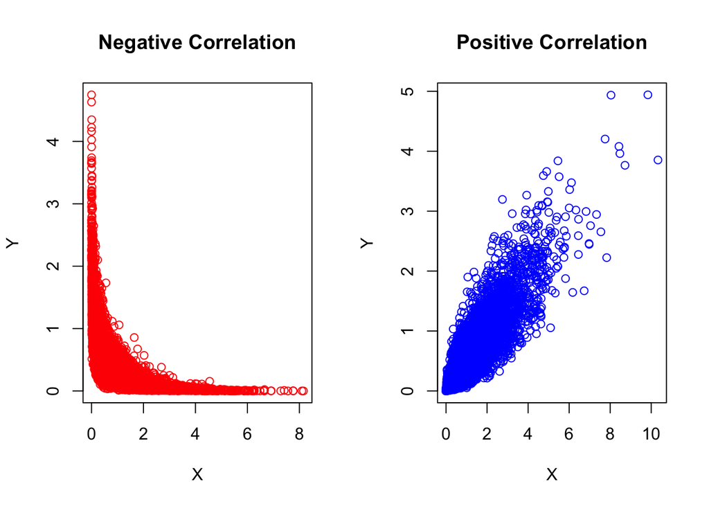

```r
# Define the copula
# Here, for example, is a correlation of 0.5; adjust as needed
# Negative correlation
myCopulaNegative <- normalCopula(-0.9, dim = 2)

# Positive correlation
myCopulaPositive <- normalCopula(0.9, dim = 2)

# Number of samples
n <- 10000

# Generating samples for the negative correlation
set.seed(123)
samplesNegative <- rCopula(n, myCopulaNegative)
samplesNegative[,1] <- qexp(samplesNegative[,1], rate = params1$rate)
samplesNegative[,2] <- qexp(samplesNegative[,2], rate = params2$rate)

# Generating samples for the positive correlation
set.seed(123)
samplesPositive <- rCopula(n, myCopulaPositive)
samplesPositive[,1] <- qexp(samplesPositive[,1], rate = params1$rate)
samplesPositive[,2] <- qexp(samplesPositive[,2], rate = params2$rate)

# Plotting
par(mfrow = c(1, 2))
plot(samplesNegative, col = 'red', main = 'Negative Correlation', xlab = 'X', ylab = 'Y')
plot(samplesPositive, col = 'blue', main = 'Positive Correlation', xlab = 'X', ylab = 'Y')
```

```r
# Tus parámetros y código previo aquí...

# Calcula las estadísticas para las muestras generadas
# Puedes hacerlo tanto para la correlación negativa como para la positiva

# Para la correlación negativa (o positiva, según corresponda)
X_Negative <- samplesNegative[,1]
Y_Negative <- samplesNegative[,2]
Sum_XY_Negative <- X_Negative + Y_Negative

# Varianza
var_X_Negative <- var(X_Negative)
var_Y_Negative <- var(Y_Negative)
var_Sum_XY_Negative <- var(Sum_XY_Negative)

# Desviación estándar
sd_X_Negative <- sd(X_Negative)
sd_Y_Negative <- sd(Y_Negative)
sd_Sum_XY_Negative <- sd(Sum_XY_Negative)

# Cuantil al 95%
quantile_X_95_Negative <- quantile(X_Negative, 0.95)
quantile_Y_95_Negative <- quantile(Y_Negative, 0.95)
quantile_Sum_XY_95_Negative <- quantile(Sum_XY_Negative, 0.95)

# Valor esperado condicional de la cola al 95%
mean_X_Tail_95_Negative <- mean(X_Negative[X_Negative > quantile_X_95_Negative])
mean_Y_Tail_95_Negative <- mean(Y_Negative[Y_Negative > quantile_Y_95_Negative])
mean_Sum_XY_Tail_95_Negative <- mean(Sum_XY_Negative[Sum_XY_Negative > quantile_Sum_XY_95_Negative])

# Imprimir los resultados
cat("Correlación Negativa:\n")
```

```
Correlación Negativa:
```

```r
cat("Varianzas: X =", var_X_Negative, ", Y =", var_Y_Negative, ", X + Y =", var_Sum_XY_Negative, "\n")
```

```
Varianzas: X = 1.011644 , Y = 0.2467184 , X + Y = 0.6637279
```

```r
cat("Desviaciones Estándar: X =", sd_X_Negative, ", Y =", sd_Y_Negative, ", X + Y =", sd_Sum_XY_Negative, "\n")
```

```
Desviaciones Estándar: X = 1.005805 , Y = 0.4967076 , X + Y = 0.814695
```

```r
cat("Cuantiles al 95%: X =", quantile_X_95_Negative, ", Y =", quantile_Y_95_Negative, ", X + Y =", quantile_Sum_XY_95_Negative, "\n")
```

```
Cuantiles al 95%: X = 3.020664 , Y = 1.47222 , X + Y = 3.121002
```

```r
cat("Valor esperado condicional de la cola al 95%: X =", mean_X_Tail_95_Negative, ", Y =", mean_Y_Tail_95_Negative, ", X + Y =", mean_Sum_XY_Tail_95_Negative, "\n")
```

```
Valor esperado condicional de la cola al 95%: X = 4.020712 , Y = 1.982904 , X + Y = 4.075715
```

```r
# Repite los cálculos para la correlación positiva si es necesario
```

```r
# Suponiendo que ya tienes definidos samplesPositive, y los parámetros params1 y params2

# Variables para la correlación positiva
X_Positive <- samplesPositive[,1]
Y_Positive <- samplesPositive[,2]
Sum_XY_Positive <- X_Positive + Y_Positive

# Varianza
var_X_Positive <- var(X_Positive)
var_Y_Positive <- var(Y_Positive)
var_Sum_XY_Positive <- var(Sum_XY_Positive)

# Desviación estándar
sd_X_Positive <- sd(X_Positive)
sd_Y_Positive <- sd(Y_Positive)
sd_Sum_XY_Positive <- sd(Sum_XY_Positive)

# Cuantil al 95%
quantile_X_95_Positive <- quantile(X_Positive, 0.95)
quantile_Y_95_Positive <- quantile(Y_Positive, 0.95)
quantile_Sum_XY_95_Positive <- quantile(Sum_XY_Positive, 0.95)

# Valor esperado condicional de la cola al 95%
mean_X_Tail_95_Positive <- mean(X_Positive[X_Positive > quantile_X_95_Positive])
mean_Y_Tail_95_Positive <- mean(Y_Positive[Y_Positive > quantile_Y_95_Positive])
mean_Sum_XY_Tail_95_Positive <- mean(Sum_XY_Positive[Sum_XY_Positive > quantile_Sum_XY_95_Positive])

# Imprimir los resultados para la correlación positiva
cat("Correlación Positiva:\n")
```

```
Correlación Positiva:
```

```r
cat("Varianzas: X =", var_X_Positive, ", Y =", var_Y_Positive, ", X + Y =", var_Sum_XY_Positive, "\n")
```

```
Varianzas: X = 1.002541 , Y = 0.2510466 , X + Y = 2.139616
```

```r
cat("Desviaciones Estándar: X =", sd_X_Positive, ", Y =", sd_Y_Positive, ", X + Y =", sd_Sum_XY_Positive, "\n")
```

```
Desviaciones Estándar: X = 1.00127 , Y = 0.5010455 , X + Y = 1.462743
```

```r
cat("Cuantiles al 95%: X =", quantile_X_95_Positive, ", Y =", quantile_Y_95_Positive, ", X + Y =", quantile_Sum_XY_95_Positive, "\n")
```

```
Cuantiles al 95%: X = 3.013108 , Y = 1.473666 , X + Y = 4.390258
```

```r
cat("Valor esperado condicional de la cola al 95%: X =", mean_X_Tail_95_Positive, ", Y =", mean_Y_Tail_95_Positive, ", X + Y =", mean_Sum_XY_Tail_95_Positive, "\n")
```

```
Valor esperado condicional de la cola al 95%: X = 4.008199 , Y = 2.014169 , X + Y = 5.877844
```

### Cópula Marshall-Olkin

$$C(u,v)=(1-u)(1-v)\textbf{mín}\{(1-u)^{-\alpha_{1}},(1-u)^{-\alpha_{1}}\}$$

### Arquimediana 1

$$C(u,v)=\phi^{-1}(\phi(u)+\phi(v))$$

donde $\phi(u)=(-\ln u)^{\theta}$

### Arquimediana 2

$$C(u,v)=\phi^{-1}(\phi(u)+\phi(v))$$

donde $\phi(u)=\ln(1-\theta\ln(u))$

### Arquimediana 3

$$C(u,v)=\phi^{-1}(\phi(u)+\phi(v))$$

donde $\phi(u)=(1-\ln(u))^{\theta}-1$

## Caso Pareto

Tenemos las siguientes variables aleatorias:

$$X\sim \textbf{Pareto}(\alpha, 2\nu)$$

$$Y\sim \textbf{Pareto}(\alpha, \nu)$$

donde $F_{x}(x)=1-\left(\frac{2\nu}{x+2\nu}\right)^{\alpha}$ y $F_{y}(y)=1-\left(\frac{\nu}{y+\nu}\right)^{\alpha}$

### Cópula Gaussiana

$$C(u,v)=\Phi_{2}(\Phi^{-1}(u),\Phi^{-1}(v))$$

### Cópula Marshall-Olkin

$$C(u,v)=(1-u)(1-v)\textbf{mín}\{(1-u)^{-\alpha_{1}},(1-u)^{-\alpha_{1}}\}$$

### Arquimediana 1

$$C(u,v)=\phi^{-1}(\phi(u)+\phi(v))$$

donde $\phi(u)=(-\ln u)^{\theta}$

### Arquimediana 2

$$C(u,v)=\phi^{-1}(\phi(u)+\phi(v))$$

donde $\phi(u)=\ln(1-\theta\ln(u))$

### Arquimediana 3

$$C(u,v)=\phi^{-1}(\phi(u)+\phi(v))$$

donde $\phi(u)=(1-\ln(u))^{\theta}-1$